# Assignment 7

Sonali Singh

# Lab-Logistic Regression

```r
# Knowledge Mining: Logistic Regression
# File: Lab_logisticregression01.R
# Theme: Logistic regression
# Adapted from ISLR Chapter 4 Lab

# Load ISLR library

require(ISLR)
# Check dataset Smarket
?Smarket
names(Smarket)
```

```
## [1] "Year"      "Lag1"      "Lag2"      "Lag3"      "Lag4"      "Lag5"
## [7] "Volume"    "Today"     "Direction"
```

```r
summary(Smarket)
```

```
##       Year           Lag1                Lag2                Lag3
##  Min.   :2001   Min.   :-4.922000   Min.   :-4.922000   Min.   :-4.922000
##  1st Qu.:2002   1st Qu.:-0.639500   1st Qu.:-0.639500   1st Qu.:-0.640000
##  Median :2003   Median : 0.039000   Median : 0.039000   Median : 0.038500
##  Mean   :2003   Mean   : 0.003834   Mean   : 0.003919   Mean   : 0.001716
##  3rd Qu.:2004   3rd Qu.: 0.596750   3rd Qu.: 0.596750   3rd Qu.: 0.596750
##  Max.   :2005   Max.   : 5.733000   Max.   : 5.733000   Max.   : 5.733000
##       Lag4                Lag5              Volume           Today
##  Min.   :-4.922000   Min.   :-4.92200   Min.   :0.3561   Min.   :-4.922000
##  1st Qu.:-0.640000   1st Qu.:-0.64000   1st Qu.:1.2574   1st Qu.:-0.639500
##  Median : 0.038500   Median : 0.03850   Median :1.4229   Median : 0.038500
##  Mean   : 0.001636   Mean   : 0.00561   Mean   :1.4783   Mean   : 0.003138
##  3rd Qu.: 0.596750   3rd Qu.: 0.59700   3rd Qu.:1.6417   3rd Qu.: 0.596750
##  Max.   : 5.733000   Max.   : 5.73300   Max.   :3.1525   Max.   : 5.733000
##  Direction
##  Down:602
##  Up  :648
##
##
##
##
```

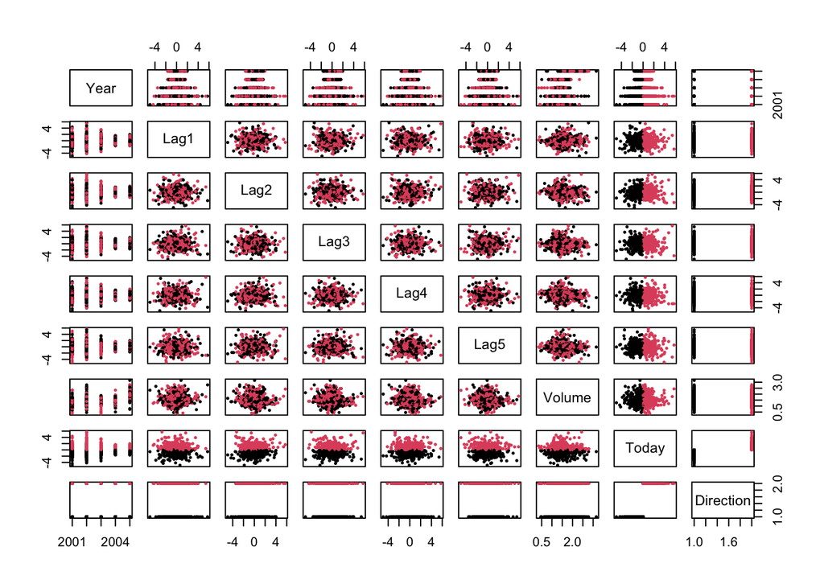

```r
# Create a dataframe for data browsing
sm=Smarket

# Bivariate Plot of inter-lag correlations
pairs(Smarket,col=Smarket$Direction,cex=.5, pch=20)
```

```r
# Logistic regression
glm.fit=glm(Direction~Lag1+Lag2+Lag3+Lag4+Lag5+Volume,
            data=Smarket,family=binomial)
summary(glm.fit)
```

```
##
## Call:
## glm(formula = Direction ~ Lag1 + Lag2 + Lag3 + Lag4 + Lag5 +
##     Volume, family = binomial, data = Smarket)
##
## Coefficients:
##              Estimate Std. Error z value Pr(>|z|)
## (Intercept) -0.126000   0.240736  -0.523    0.601
## Lag1        -0.073074   0.050167  -1.457    0.145
## Lag2        -0.042301   0.050086  -0.845    0.398
## Lag3         0.011085   0.049939   0.222    0.824
## Lag4         0.009359   0.049974   0.187    0.851
## Lag5         0.010313   0.049511   0.208    0.835
## Volume       0.135441   0.158360   0.855    0.392
##
## (Dispersion parameter for binomial family taken to be 1)
##
##     Null deviance: 1731.2  on 1249  degrees of freedom
## Residual deviance: 1727.6  on 1243  degrees of freedom
## AIC: 1741.6
##
## Number of Fisher Scoring iterations: 3
```

```r
glm.probs=predict(glm.fit,type="response")
glm.probs[1:5]
```

```
##         1         2         3         4         5
## 0.5070841 0.4814679 0.4811388 0.5152224 0.5107812
```

```r
glm.pred=ifelse(glm.probs>0.5,"Up","Down")
attach(Smarket)
table(glm.pred,Direction)
```

```
##         Direction
## glm.pred Down  Up
##     Down  145 141
##     Up    457 507
```

```r
mean(glm.pred==Direction)
```

```
## [1] 0.5216
```

```r
# Make training and test set for prediction
train = Year<2005
glm.fit=glm(Direction~Lag1+Lag2+Lag3+Lag4+Lag5+Volume,
            data=Smarket,family=binomial, subset=train)
glm.probs=predict(glm.fit,newdata=Smarket[!train,],type="response")
glm.pred=ifelse(glm.probs >0.5,"Up","Down")
Direction.2005=Smarket$Direction[!train]
table(glm.pred,Direction.2005)
```

```
##         Direction.2005
## glm.pred Down Up
##     Down   77 97
##     Up     34 44
```

```r
mean(glm.pred==Direction.2005)
```

```
## [1] 0.4801587
```

```r
#Fit smaller model
glm.fit=glm(Direction~Lag1+Lag2,
            data=Smarket,family=binomial, subset=train)
glm.probs=predict(glm.fit,newdata=Smarket[!train,],type="response")
glm.pred=ifelse(glm.probs >0.5,"Up","Down")
table(glm.pred,Direction.2005)
```

```
##         Direction.2005
## glm.pred Down  Up
##     Down   35  35
##     Up     76 106
```

```r
mean(glm.pred==Direction.2005)
```

```
## [1] 0.5595238
```

```r
# Check accuracy rate
106/(76+106)
```

```
## [1] 0.5824176
```

```r
# Can you interpret the results?
```

### Interpretation

1. **Data Summary and Structure**: The **`Smarket`** dataset contains daily percentage returns for the S&P 500 stock index from 2001 to 2005, characterized by features like **`Lag1`** to **`Lag5`**, **`Volume`**, and the response variable **`Direction`** (indicating whether the market went up or down).
2. **Pairwise Correlations**: The **`pairs`** plot visually assesses correlations and distributions of the variables against each other. Colored by the direction of market movement, it potentially identifies patterns or relationships critical for predictive modeling.
3. **Logistic Regression Model Development**:
   - **Initial Model**: A logistic regression model is fit with directional movements as a function of lags and volume. The coefficients are estimated, but none of the predictors appear statistically significant (p-values > 0.05), suggesting they may not reliably predict market direction.
   - **Performance**: The classification accuracy of the initial model on the dataset used for fitting is approximately 52.16%, which barely exceeds a random guess in a balanced binary classification.
4. **Model Validation**:
   - **Setup**: The data is split into a training set (before 2005) and a test set (2005 data).
   - **Refitted Model Performance on 2005 Data**: When the full model is applied to 2005 data, the accuracy is about 48.02%, indicating poor generalization, possibly due to overfitting or non-predictive lag variables.
   - **Simplified Model**: A simplified model using only **`Lag1`** and **`Lag2`** improves accuracy on the 2005 data to 55.95%. This suggests reducing complexity may help in avoiding overfitting and enhancing the model’s predictive accuracy.
5. **Accuracy Rate Calculation**: The final calculation, **`106/(76+106) = 58.24%`**, suggests a slightly better performance of the simplified model, specifically in the true positive predictions within the 2005 subset.

The overall effectiveness of lagged returns and volume in predicting market direction appears limited. The fluctuating accuracy rates highlight the challenges of financial time series forecasting, where past performance may not always predict future movements effectively.

## **Review ISLR Chapter 4 and Answers**

**2a. What is/are the requirement(s) of LDA?** Linear Discriminant Analysis (LDA) requires that the predictors are normally distributed within each class, and that the classes have similar covariance matrices.

**2b. How LDA is different from Logistic Regression?** LDA assumes that the predictors are normally distributed and the classes have the same covariance structure. Logistic regression does not make these assumptions and instead uses a logistic function to model the probability that an observation belongs to a particular class.

**2c. What is ROC?** ROC (Receiver Operating Characteristic) is a graphical plot that illustrates the diagnostic ability of a binary classifier system as its discrimination threshold is varied. It is created by plotting the true positive rate (TPR) against the false positive rate (FPR) at various threshold settings.

**2d. What is sensitivity and specificity? Which is more important in your opinion?** Sensitivity (or true positive rate) is the measure of the proportion of actual positives correctly identified. Specificity (or true negative rate) is the measure of the proportion of actual negatives correctly identified. The importance of each depends on the context; sensitivity might be prioritized in medical testing to avoid missing a diagnosis, while specificity might be emphasized in spam detection to avoid marking legitimate emails as spam.

### **Question 3-Calculate the prediction error from the following:**

To calculate the prediction error from the provided table:

- **True Negatives (TN)**: 9,644
- **True Positives (TP)**: 81
- **False Negatives (FN)**: 252
- **False Positives (FP)**: 23

The prediction error can be calculated as the sum of the instances where the predictions were incorrect over the total number of instances.

[figure not shown]

to compute this value:

[figure not shown]

So, the prediction error is 0.0275, or 2.75%.